# Quickstart

```python
from mcbj import *
```

### Set the date of the measurement, which then sets the path to the measurement data

```python
date = "23_08_08"
home_folder = Path(f'//DATACENTER/BreakJunction_group/BJ_Data/{date}')
```

### Cretae a trace_pair instance:

```python
trace_pair=TracePair(load_from=home_folder, trace=75)
```

Plot the trace pair:

```
(34.0, 38.0)
```

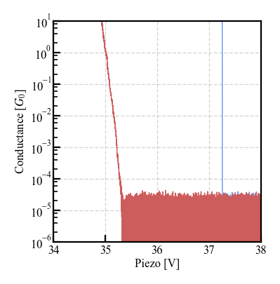

```python
ax = trace_pair.plot_trace_pair(dpi=200)
ax.set_xlim(34, 38)
```

Align at $0.5\;G_{0}$ an then plot

```
0.5
```

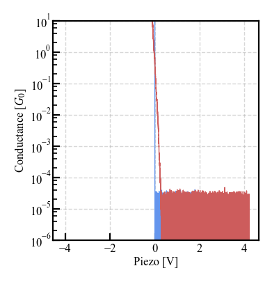

```python
trace_pair.align_trace(0.5)
print(trace_pair.align_at)
ax = trace_pair.plot_trace_pair(dpi=200, aligned=True)
```

### Create a histogram instance:

this tells the constructor that we want to calculate the statistics from trace `start_trace` until `end_trace`, in the given `conductance range`, you can also define the scaling (`conductance_log_scale=True` means logarithmic conductance scaling), the number of bins is `conductance_bins_num`, `conductance_bins_mode='total'` means that you have a total of 100 bins, see documentation for more info.

```python
hist = Histogram(folder=home_folder,
                 start_trace=1, end_trace=100,
                 conductance_range=(1e-5, 10),
                 conductance_log_scale=True,
                 conductance_bins_num=100,
                 conductance_bins_mode='total')
```

Now that you have a histogram instance, you can calculate the statistics:

```python
hist.calc_stats(align_at=0.5,  # at which conductance value to align the traces
                interpolate=True,  # use interpolation for the alignment of traces
                range_pull=(-0.5, 1),  # x axis range pull
                range_push=(-0.5, 1.5))  # x axis range push
```

```
Pull 2D histogram created from 100 traces
Push 2D histogram created from 100 traces
```

`hist.calc_stats` calculates the temporal histogram, the 1D & 2D histograms, and the plateau length histogram (of the $1G_0$ plateau by default)

Now that you calculated them, you can plot them:

Temporal histogram:

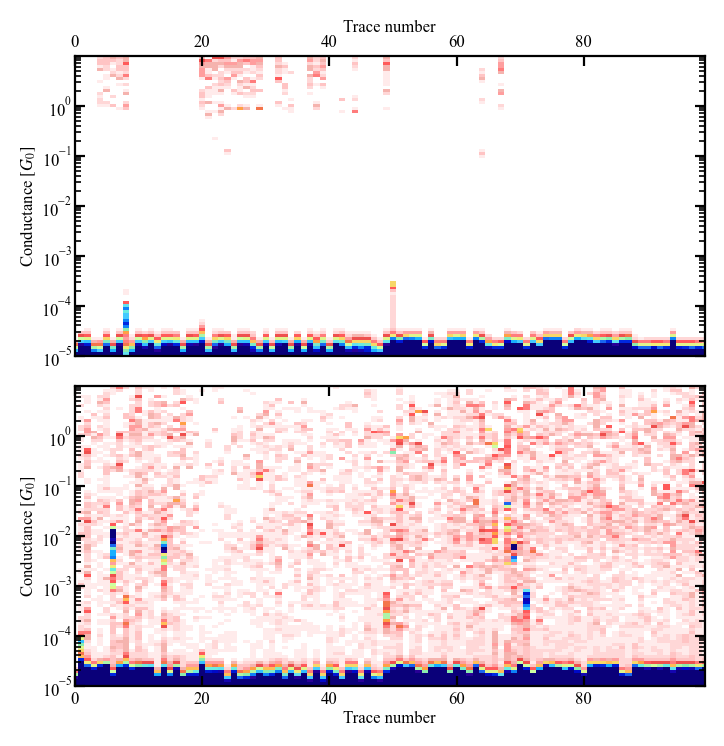

```python
ax_pull, ax_push = hist.plot_temporal_hist(dpi=200, vmax_pull=1000, vmax_push=1000)
```

1D histogram:

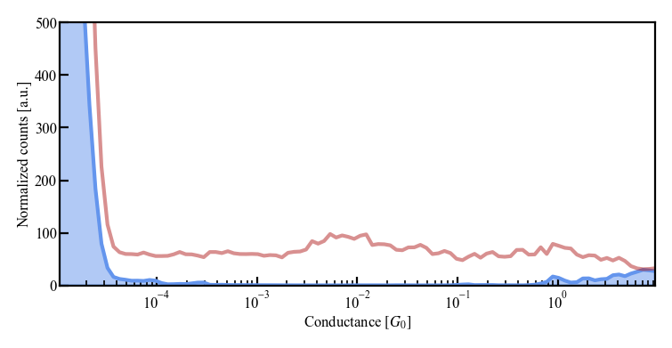

```python
ax = hist.plot_hist_1d(dpi=200, ylims=(0, 500))
```

2D histogram:

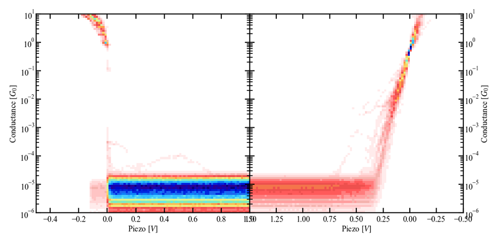

```python
ax_pull, ax_push = hist.plot_hist_2d_both(dpi=200)
```

You can also calculate the correlation:

```python
hist.calc_corr_hist_2d()
```

Then plot:

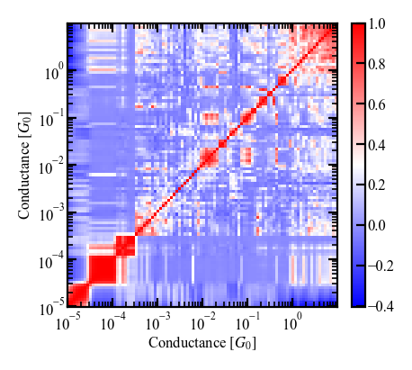

```python
ax = hist.plot_corr('pull', dpi=200)
```

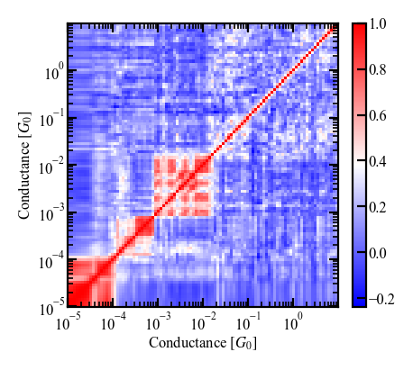

```python
ax = hist.plot_corr('push', dpi=200)
```

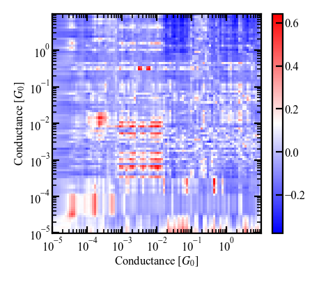

```python
ax = hist.plot_corr('cross', dpi=200)
```